# hwk_13

Holden Jones

2025-05-14

```r
library(tidyverse)
library(lme4)
```

```r
library(ggeffects)
library(sjPlot)

ohia <- read_csv('data/ohia_merged.csv')
```

#1.

Using the seedlings that were harvested after the press drought treatment, analyze how seedling height varies among treatments and populations.

subset only harvested seedlings

```r
harvest <- ohia %>%
  filter(Fate == "harvest")
```

Be sure to include Block in your models, and think about which terms in the model should be random effects, which should be fixed effects, which should be fixed:random interactions, and which should be fixed:fixed interactions (you will need all four). - height as response variable - block definitely as a random effect - drought definitely as fixed effect - population definitely as fixed effect - drought and population as interaction

first, look at dist. of response variable

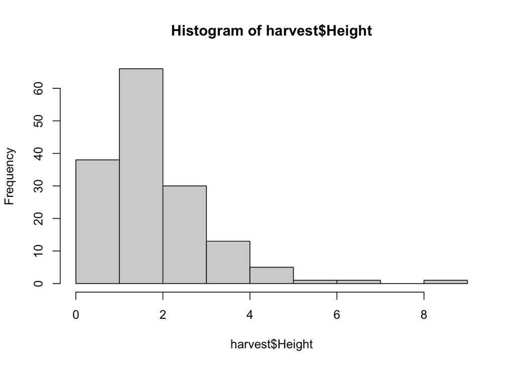

```r
hist(harvest$Height) # close to normal, long tail
```

Specifically, set up models to test whether populations differ in height, whether the press drought treatment affects height, and whether populations differ in how press drought affects height.

```r
mod_height_1 <- lmer(Height ~ Drought +
                     (Drought | Population) +
                     (1 | Block),
                   data = harvest
                   )
```

```
## boundary (singular) fit: see help('isSingular')
```

```r
summary(mod_height_1)
```

```
## Linear mixed model fit by REML ['lmerMod']
## Formula: Height ~ Drought + (Drought | Population) + (1 | Block)
##    Data: harvest
##
## REML criterion at convergence: 490.6
##
## Scaled residuals:
##     Min      1Q  Median      3Q     Max
## -1.5679 -0.6001 -0.1459  0.3756  4.9434
##
## Random effects:
##  Groups     Name           Variance Std.Dev. Corr
##  Population (Intercept)    0.07870  0.2805
##             Droughtdrought 0.14131  0.3759   1.00
##  Block      (Intercept)    0.09173  0.3029
##  Residual                  1.22274  1.1058
## Number of obs: 155, groups:  Population, 16; Block, 9
##
## Fixed effects:
##                Estimate Std. Error t value
## (Intercept)      1.7797     0.1807   9.849
## Droughtdrought  -0.1373     0.2174  -0.632
##
## Correlation of Fixed Effects:
##             (Intr)
## Droghtdrght -0.137
## optimizer (nloptwrap) convergence code: 0 (OK)
## boundary (singular) fit: see help('isSingular')
```

Make appropriate plots of model results and describe the magnitude of any apparent relationships.

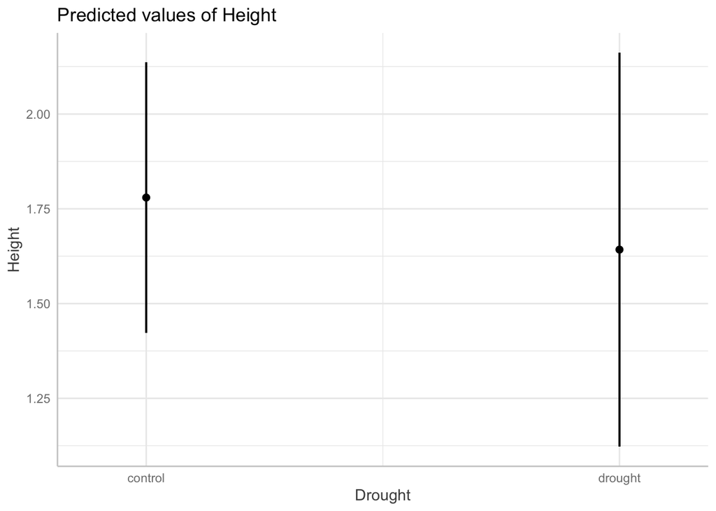

```r
plot(ggpredict(mod_height_1, terms = c("Drought")))
```

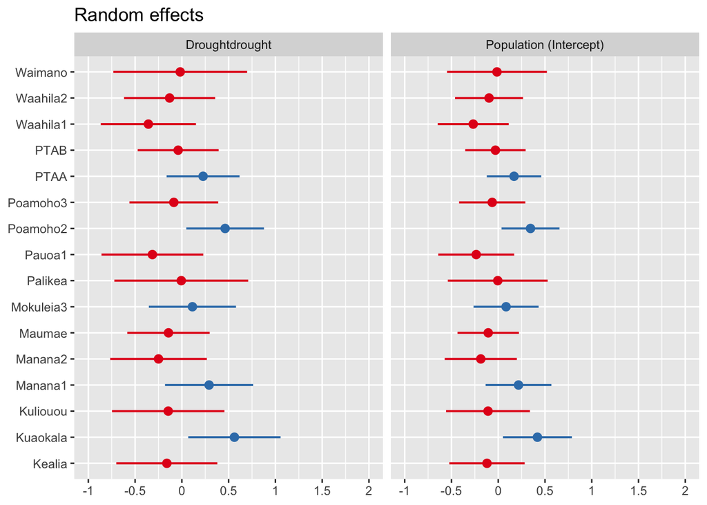

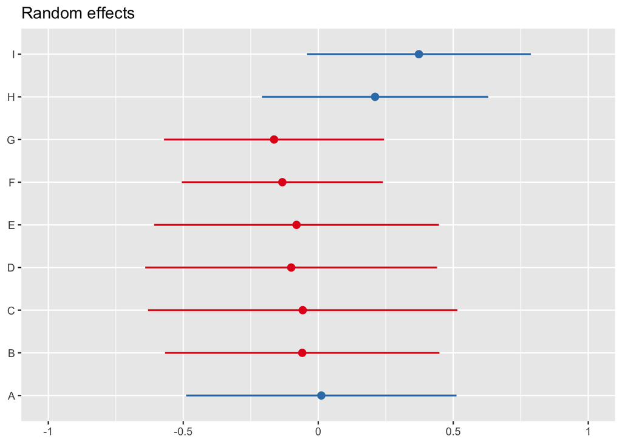

```r
# drought has no impact on height
plot_model(mod_height_1, type = "re")
```

```r
# population v small impact, Poa, Kua diff
# block has no impact on height - this is good!
```

Next, set up models to test whether historical rainfall at a site predicts the height of seedlings, and whether historical rainfall at a site predicts the effect of press drought on height.

```r
mod_height_2 <- lmer(Height ~ MAR * Drought +
                    (1|Population) + (1 | Block),
                    data = harvest)
summary(mod_height_2)
```

```
## Linear mixed model fit by REML ['lmerMod']
## Formula: Height ~ MAR * Drought + (1 | Population) + (1 | Block)
##    Data: harvest
##
## REML criterion at convergence: 514.8
##
## Scaled residuals:
##     Min      1Q  Median      3Q     Max
## -1.6182 -0.6355 -0.1253  0.4165  5.1274
##
## Random effects:
##  Groups     Name        Variance Std.Dev.
##  Population (Intercept) 0.1888   0.4345
##  Block      (Intercept) 0.1450   0.3808
##  Residual               1.2494   1.1178
## Number of obs: 155, groups:  Population, 16; Block, 9
##
## Fixed effects:
##                      Estimate Std. Error t value
## (Intercept)         1.9359078  0.3768375   5.137
## MAR                -0.0008694  0.0013641  -0.637
## Droughtdrought      0.0340381  0.3380472   0.101
## MAR:Droughtdrought -0.0006078  0.0013213  -0.460
##
## Correlation of Fixed Effects:
##             (Intr) MAR    Drghtd
## MAR         -0.813
## Droghtdrght -0.350  0.316
## MAR:Drghtdr  0.283 -0.362 -0.826
```

Make appropriate plots of model results and describe the magnitude of any apparent relationships.

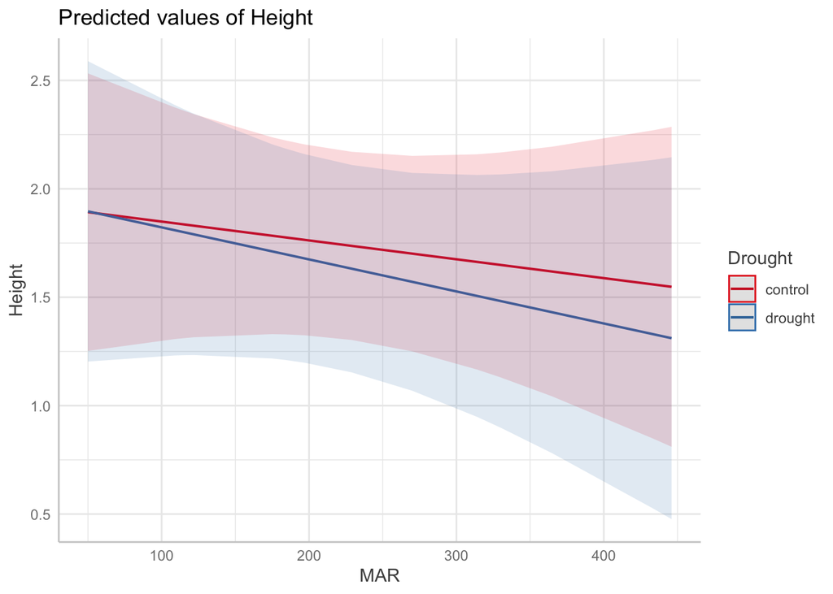

```r
plot(ggpredict(mod_height_2, terms = c("MAR", "Drought")))
```

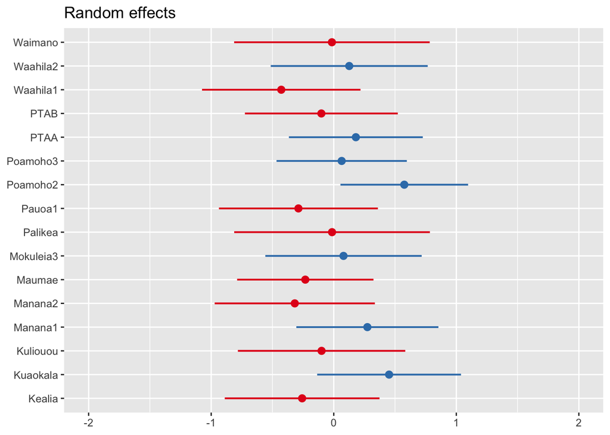

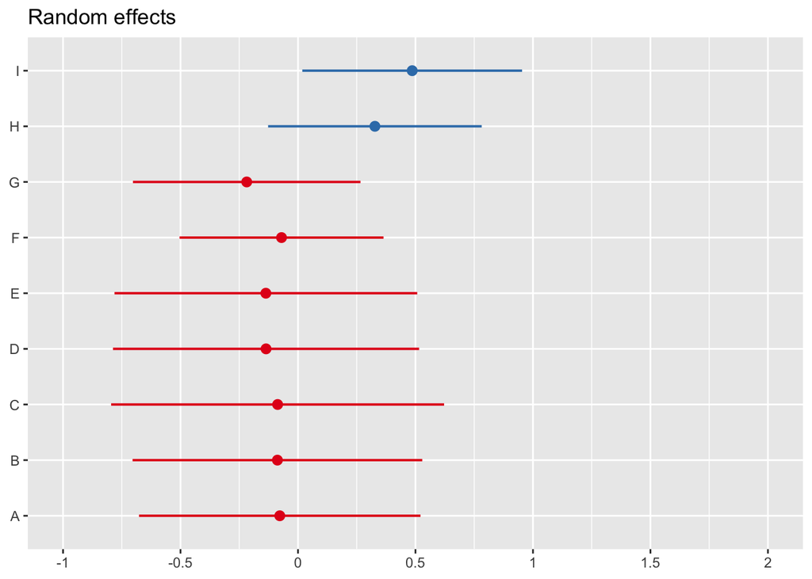

```r
# no correlation between historical rainfall and height
# no sig difference in this relationship for control vs. drought
plot_model(mod_height_2, type = "re")
```

```r
# only Poamoho 2 sig higher height, not by much
# block I barely sig taller than the others - probably not meaningful
```

Finally, set up models to test whether historical evapotranspiration at a site predicts the height of seedlings, and whether historical evapotranspiration at a site predicts the effect of press drought on height.

```r
mod_height_3 <- lmer(Height ~ MET * Drought +
                    (1|Population) + (1 | Block),
                    data = harvest)
summary(mod_height_3)
```

```
## Linear mixed model fit by REML ['lmerMod']
## Formula: Height ~ MET * Drought + (1 | Population) + (1 | Block)
##    Data: harvest
##
## REML criterion at convergence: 517.6
##
## Scaled residuals:
##     Min      1Q  Median      3Q     Max
## -1.5596 -0.6002 -0.1365  0.3981  5.2305
##
## Random effects:
##  Groups     Name        Variance Std.Dev.
##  Population (Intercept) 0.16757  0.4093
##  Block      (Intercept) 0.09514  0.3085
##  Residual               1.26296  1.1238
## Number of obs: 155, groups:  Population, 16; Block, 9
##
## Fixed effects:
##                      Estimate Std. Error t value
## (Intercept)         2.3382340  0.5592575   4.181
## MET                -0.0006722  0.0006007  -1.119
## Droughtdrought     -0.2919401  0.5198214  -0.562
## MET:Droughtdrought  0.0002477  0.0005938   0.417
##
## Correlation of Fixed Effects:
##             (Intr) MET    Drghtd
## MET         -0.934
## Droghtdrght -0.406  0.390
## MET:Drghtdr  0.368 -0.400 -0.930
```

Make appropriate plots of model results and describe the magnitude of any apparent relationships.

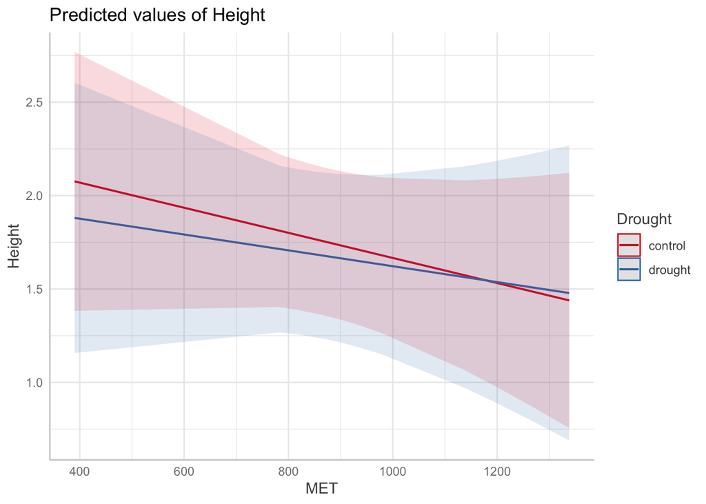

```r
plot(ggpredict(mod_height_3, terms = c("MET", "Drought")))
```

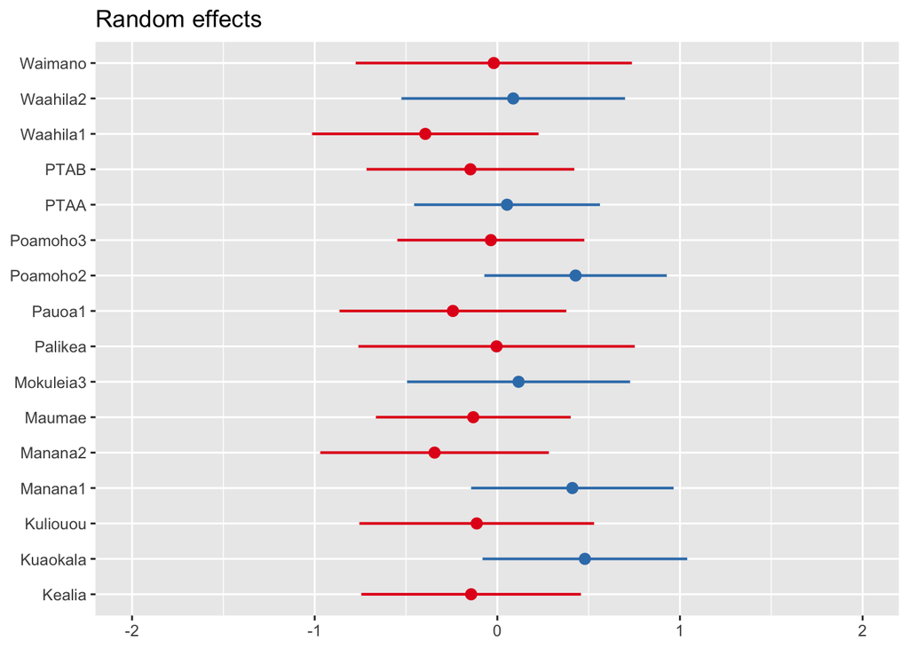

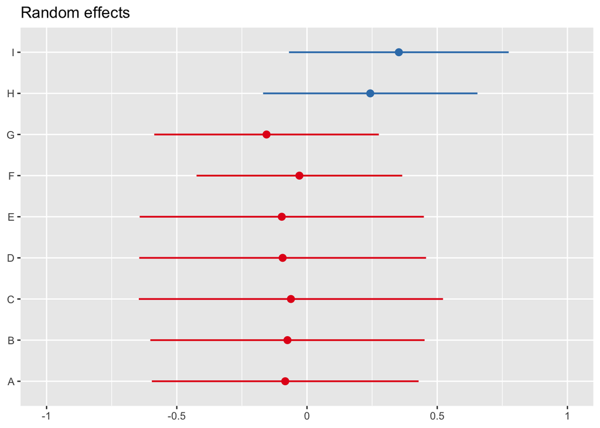

```r
# no correlation between evapotranspiration and height
# no sig difference in this relationship for control vs. drought
plot_model(mod_height_3, type = "re")
```

```r
# no random effect difference for population
# no difference for block here
```

How do you interpret the results? - drought treatment has no significant impact on height - Neither evapotranspiration or rainfall have a significant effect on height, regardless of drought treatment - There are some differences between populations in height, notably Kuakola and Puamoho 2 populations producing significantly taller seedlings - Block likely has no impact on height, which is good (note small sig higher for Block 1 in the 2nd model)

#2.

Using the seedlings that were fated to be harvested after the press drought treatment, analyze how survival during the press drought is affected by the various potential predictors.

Be sure to think about what the appropriate probability distribution is for the response variable. - survival as response variable going to be binomial dist.

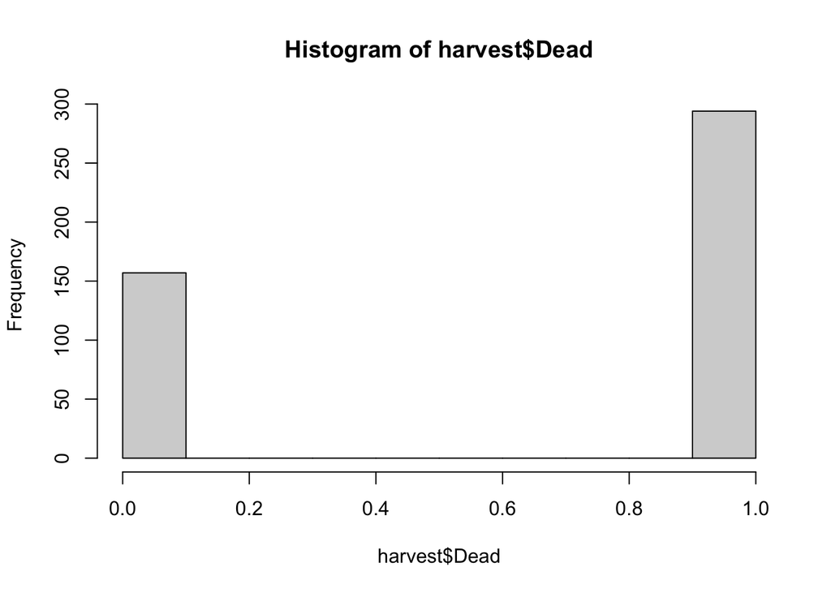

```r
hist(harvest$Dead)
```

Specifically, set up models to test whether populations vary in probability of mortality (i.e., the response column DEAD), whether the press drought treatment affects mean mortality, and whether populations vary in how mortality is affected by the press drought treatment.

```r
mod_dead_1 <- glmer(Dead ~ Drought + (Drought | Population) + (1| Block),
                 data = harvest,
                 family = binomial)
summary(mod_dead_1) # sig effect of drought
```

```
## Generalized linear mixed model fit by maximum likelihood (Laplace
##   Approximation) [glmerMod]
##  Family: binomial  ( logit )
## Formula: Dead ~ Drought + (Drought | Population) + (1 | Block)
##    Data: harvest
##
##       AIC       BIC    logLik -2*log(L)  df.resid
##     525.4     550.0    -256.7     513.4       445
##
## Scaled residuals:
##     Min      1Q  Median      3Q     Max
## -3.3439 -0.8278  0.3393  0.5974  1.7268
##
## Random effects:
##  Groups     Name           Variance Std.Dev. Corr
##  Population (Intercept)    0.1692   0.4113
##             Droughtdrought 0.1654   0.4067   0.43
##  Block      (Intercept)    1.1596   1.0769
## Number of obs: 451, groups:  Population, 16; Block, 9
##
## Fixed effects:
##                Estimate Std. Error z value Pr(>|z|)
## (Intercept)      0.4492     0.4181   1.074    0.283
## Droughtdrought   1.0243     0.2498   4.101 4.12e-05 ***
## ---
## Signif. codes:  0 '***' 0.001 '**' 0.01 '*' 0.05 '.' 0.1 ' ' 1
##
## Correlation of Fixed Effects:
##             (Intr)
## Droghtdrght -0.169
```

effects plots

[output not shown]

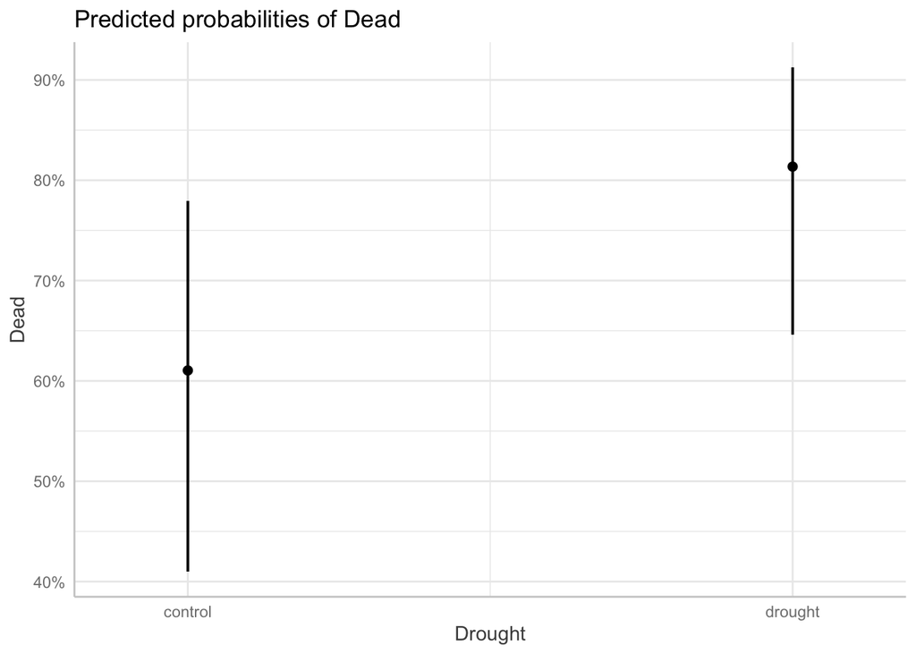

```r
plot(ggpredict(mod_dead_1, terms = "Drought"))
```

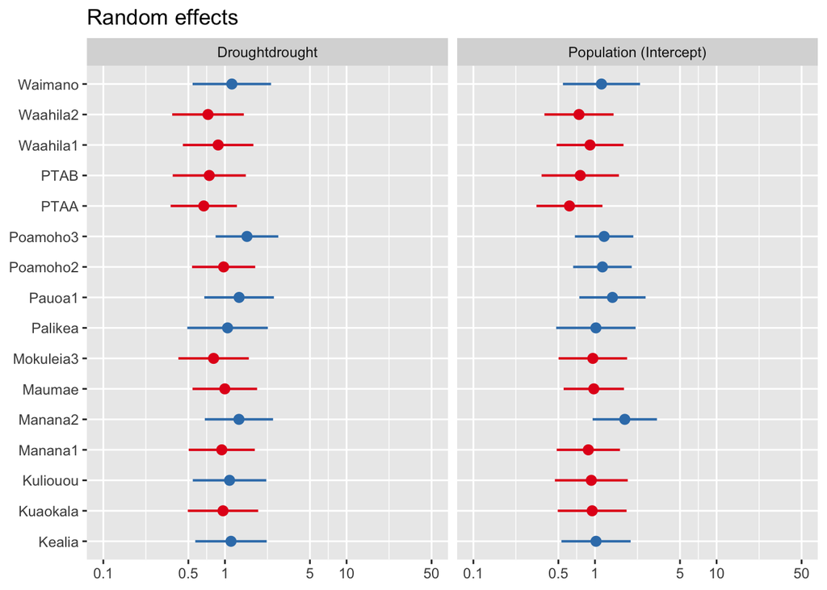

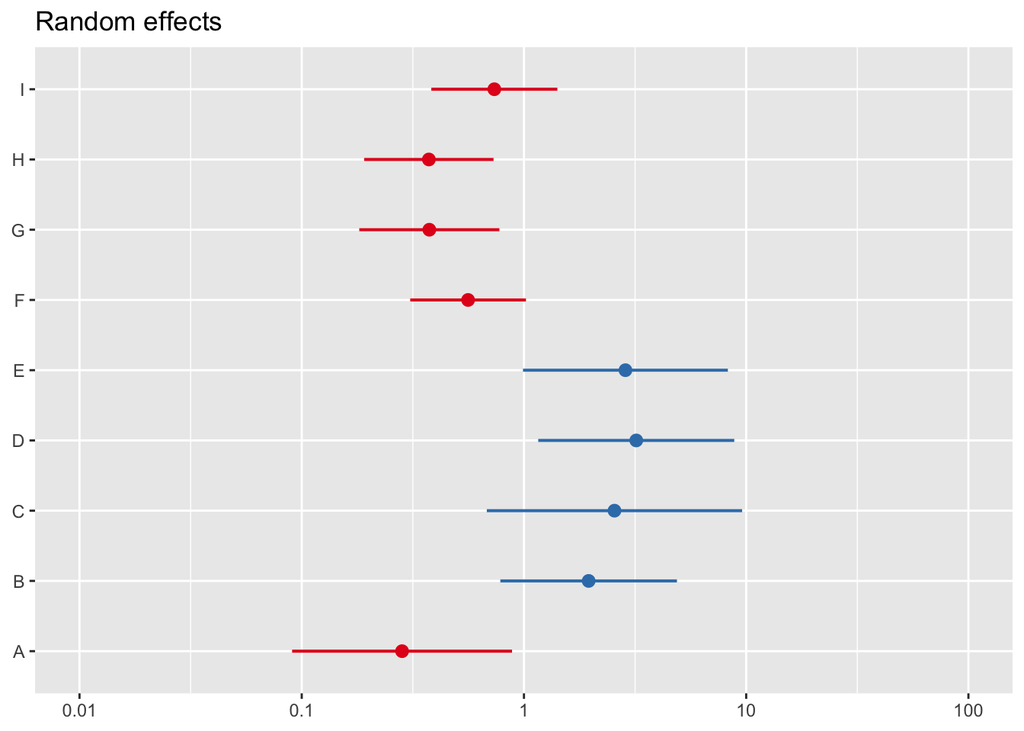

```r
# higher mortality in drought treatment
plot_model(mod_dead_1, type = "re")
```

```r
# doesn't seem like any difference in effect of drought by population
# does seem to be some differences in mortality across blocks - uh oh
```

Next, set up models to test whether historical rainfall at a site predicts mortality, and whether historical rainfall at a site predicts the effect of press drought on mortality.

```r
mod_dead_2 <- glmer(Dead ~ MAR*Drought + (1 | Population) + (1 | Block),
                 data = harvest,
                 family = binomial)
summary(mod_dead_2) # model nearly unidentifiable: very large eigenvalue
```

```
## Generalized linear mixed model fit by maximum likelihood (Laplace
##   Approximation) [glmerMod]
##  Family: binomial  ( logit )
## Formula: Dead ~ MAR * Drought + (1 | Population) + (1 | Block)
##    Data: harvest
##
##       AIC       BIC    logLik -2*log(L)  df.resid
##     516.4     541.0    -252.2     504.4       445
##
## Scaled residuals:
##     Min      1Q  Median      3Q     Max
## -4.3968 -0.8109  0.3756  0.5843  1.7398
##
## Random effects:
##  Groups     Name        Variance Std.Dev.
##  Population (Intercept) 0.001838 0.04287
##  Block      (Intercept) 1.042497 1.02103
## Number of obs: 451, groups:  Population, 16; Block, 9
##
## Fixed effects:
##                     Estimate Std. Error z value Pr(>|z|)
## (Intercept)        -0.343134   0.506117  -0.678   0.4978
## MAR                 0.003278   0.001339   2.448   0.0144 *
## Droughtdrought      0.607036   0.462176   1.313   0.1890
## MAR:Droughtdrought  0.001629   0.001636   0.995   0.3197
## ---
## Signif. codes:  0 '***' 0.001 '**' 0.01 '*' 0.05 '.' 0.1 ' ' 1
##
## Correlation of Fixed Effects:
##             (Intr) MAR    Drghtd
## MAR         -0.649
## Droghtdrght -0.448  0.523
## MAR:Drghtdr  0.383 -0.563 -0.875
## optimizer (Nelder_Mead) convergence code: 0 (OK)
## Model is nearly unidentifiable: very large eigenvalue
##  - Rescale variables?
## Model is nearly unidentifiable: large eigenvalue ratio
##  - Rescale variables?
```

```r
# MAR has sig positive effect on death
```

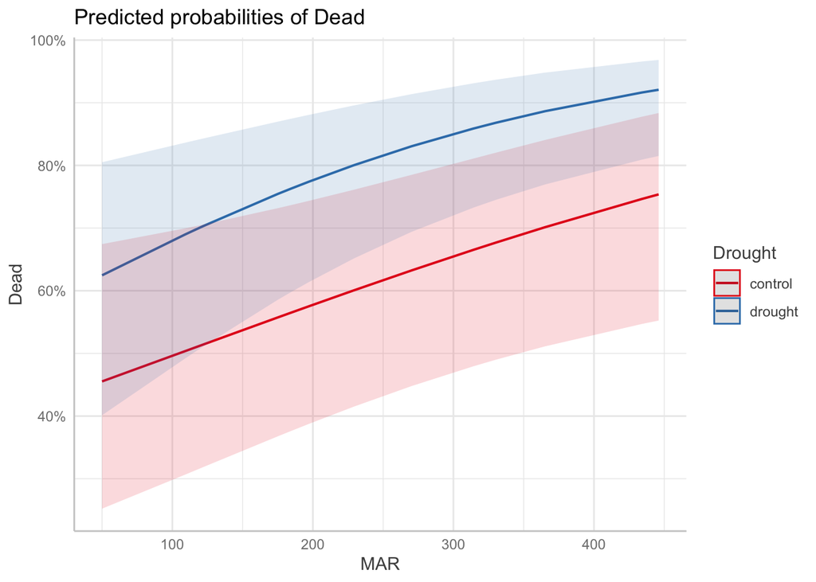

```r
plot(ggpredict(mod_dead_2, terms = c("MAR", "Drought")))
```

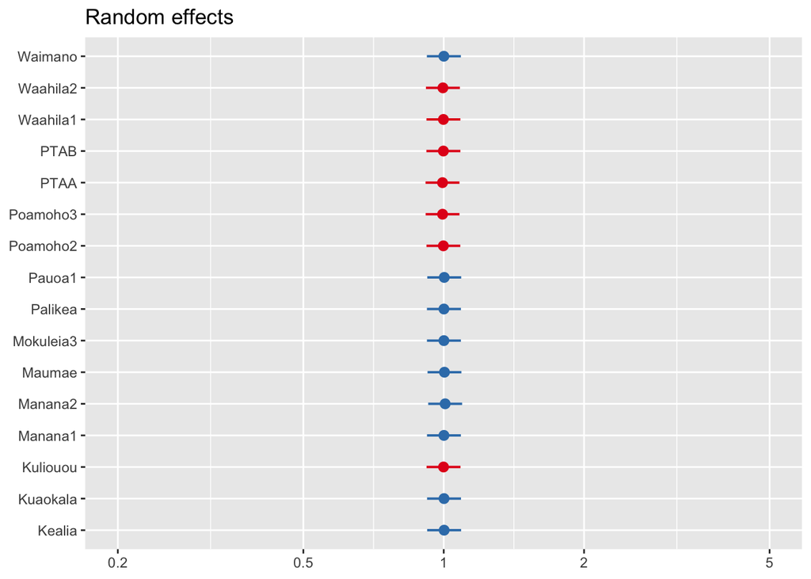

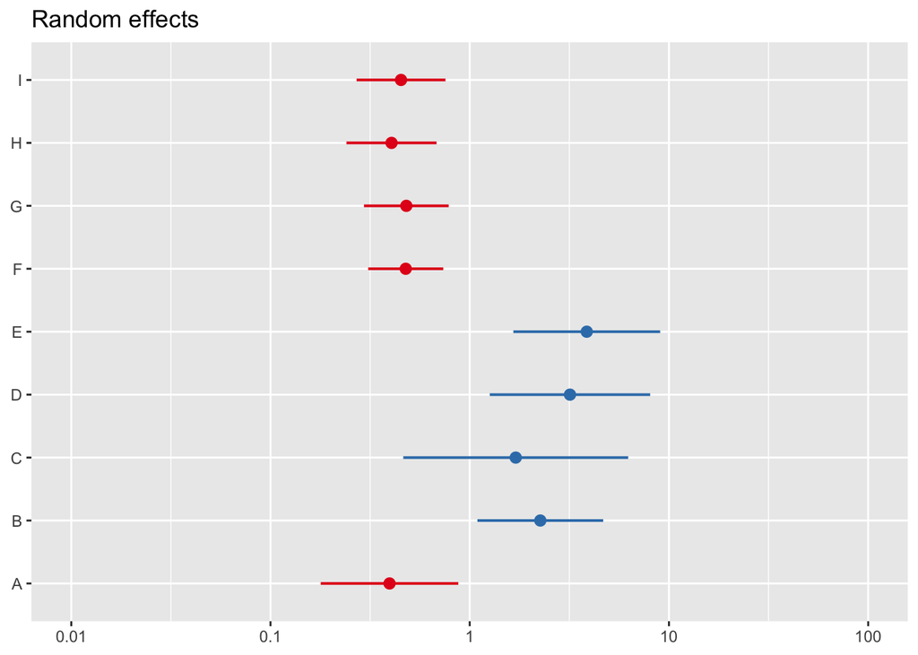

```r
# increased MAR increases the mortality of seedlings, regardless of treatment
# but this happens equally for drought vs. control treatment
plot_model(mod_dead_2, type = "re")
```

```r
# no difference across populations, suspiciously so?
# again, does seem like some differences in block for mortality - suspicious
```

Finally, set up models to test whether historical evapotranspiration at a site predicts mortality, and whether historical evapotranspiration at a site predicts the effect of press drought on mortality.

```r
mod_dead_3 <- glmer(Dead ~ MET * Drought + (1 | Population) + (1 | Block),
                 data = harvest,
                 family = binomial)
summary(mod_dead_3) # model failed to converge?
```

```
## Generalized linear mixed model fit by maximum likelihood (Laplace
##   Approximation) [glmerMod]
##  Family: binomial  ( logit )
## Formula: Dead ~ MET * Drought + (1 | Population) + (1 | Block)
##    Data: harvest
##
##       AIC       BIC    logLik -2*log(L)  df.resid
##     519.6     544.3    -253.8     507.6       445
##
## Scaled residuals:
##     Min      1Q  Median      3Q     Max
## -3.6142 -0.7679  0.3759  0.5790  1.6553
##
## Random effects:
##  Groups     Name        Variance Std.Dev.
##  Population (Intercept) 0.1484   0.3852
##  Block      (Intercept) 1.0214   1.0106
## Number of obs: 451, groups:  Population, 16; Block, 9
##
## Fixed effects:
##                      Estimate Std. Error z value Pr(>|z|)
## (Intercept)        -0.1494229  0.7989205  -0.187    0.852
## MET                 0.0006951  0.0007943   0.875    0.382
## Droughtdrought     -0.2936294  0.7716470  -0.381    0.704
## MET:Droughtdrought  0.0014625  0.0008297   1.763    0.078 .
## ---
## Signif. codes:  0 '***' 0.001 '**' 0.01 '*' 0.05 '.' 0.1 ' ' 1
##
## Correlation of Fixed Effects:
##             (Intr) MET    Drghtd
## MET         -0.870
## Droghtdrght -0.474  0.486
## MET:Drghtdr  0.451 -0.500 -0.957
## optimizer (Nelder_Mead) convergence code: 0 (OK)
## unable to evaluate scaled gradient
## Model failed to converge: degenerate  Hessian with 1 negative eigenvalues
```

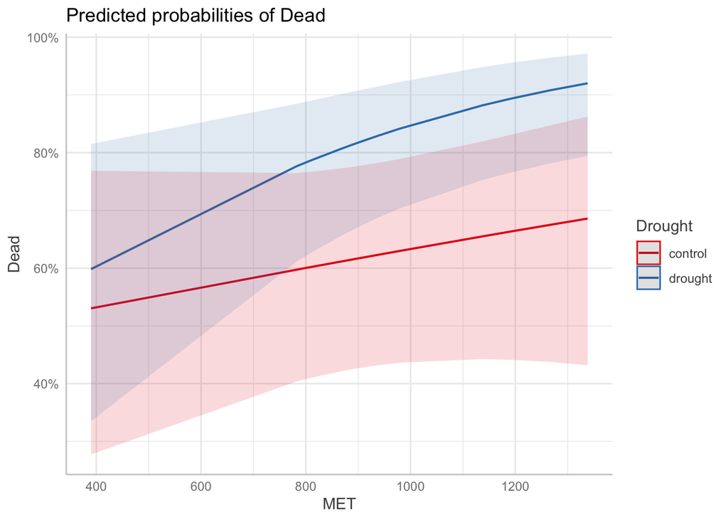

```r
plot(ggpredict(mod_dead_3, terms = c("MET", "Drought")))
```

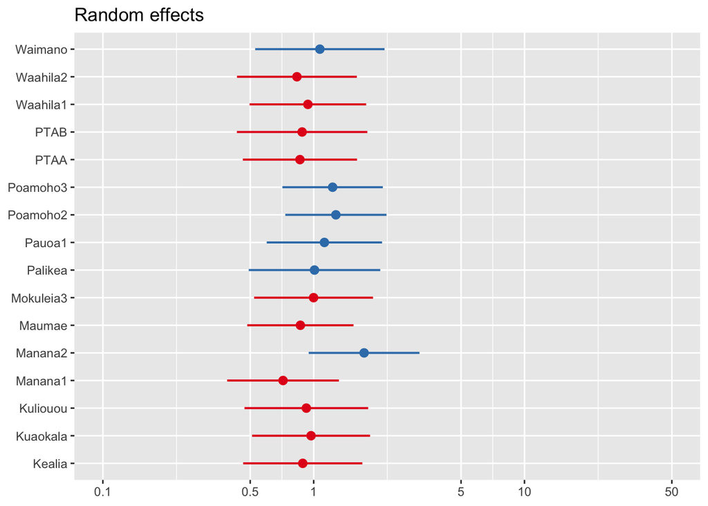

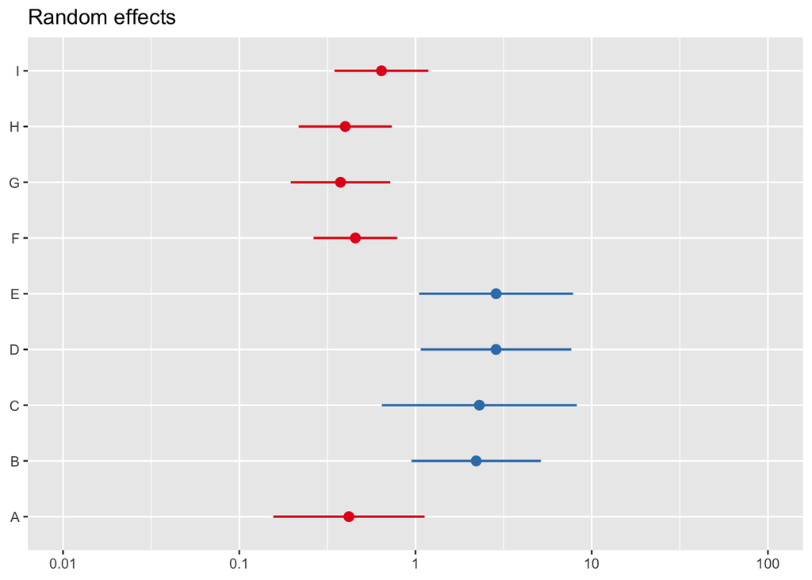

```r
# does seem that increased MAT leads to increased mortality, and that the slope
# of this relationship is different between control and drought treatments, but
# this relationship is not statistically significant
plot_model(mod_dead_3, type = "re")
```

```r
# no difference across populations, but yes sig difference in mortality across blocks
```

How do you interpret the results? - drought treatment increases mortality vs. control treatment - higher rainfall at source increases mortality, equally for control / drought - higher evapotranspiration at source does not impact mortality - no difference in mortality across source populations - see some impact of blocks in the greenhouse on mortality - not good!

#3.

Using the seedlings that were fated for the terminal drought experiment (i.e., the seedlings that were not harvested), analyze how longevity during terminal drought is affected by the various potential predictors.

subset for terminal drought seedlings

```r
drought <- ohia %>%
  filter(Fate == "terminaldrought")
```

Specifically, set up models to test whether populations vary in longevity, whether the press drought treatment affects longevity, and whether populations vary in how longevity is affected by the press drought treatment.

```r
mod_long_1 <- lmer(Longevity ~ Drought + (Drought | Population) + (1| Block),
               data = drought)
summary(mod_long_1)
```

```
## Linear mixed model fit by REML ['lmerMod']
## Formula: Longevity ~ Drought + (Drought | Population) + (1 | Block)
##    Data: drought
##
## REML criterion at convergence: 1275.8
##
## Scaled residuals:
##      Min       1Q   Median       3Q      Max
## -2.76465 -0.69110 -0.03308  0.57406  2.46697
##
## Random effects:
##  Groups     Name           Variance Std.Dev. Corr
##  Population (Intercept)     62.56    7.909
##             Droughtdrought  15.90    3.988   -0.41
##  Block      (Intercept)    155.87   12.485
##  Residual                  100.77   10.039
## Number of obs: 166, groups:  Population, 15; Block, 9
##
## Fixed effects:
##                Estimate Std. Error t value
## (Intercept)     29.5378     4.8764   6.057
## Droughtdrought   0.6495     2.0343   0.319
##
## Correlation of Fixed Effects:
##             (Intr)
## Droghtdrght -0.189
```

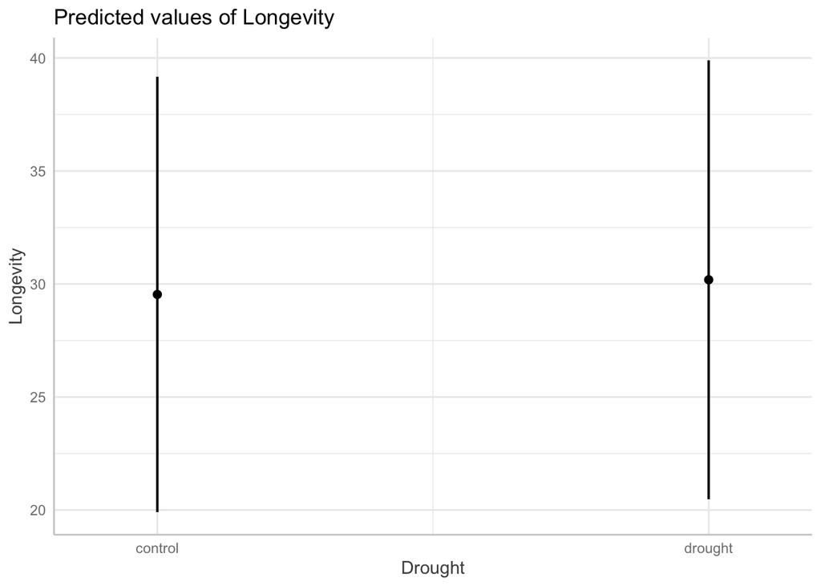

```r
plot(ggpredict(mod_long_1, terms = c("Drought")))
```

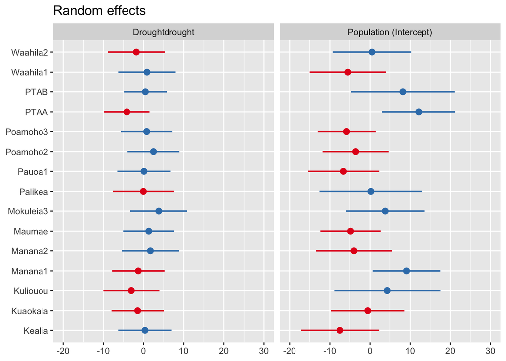

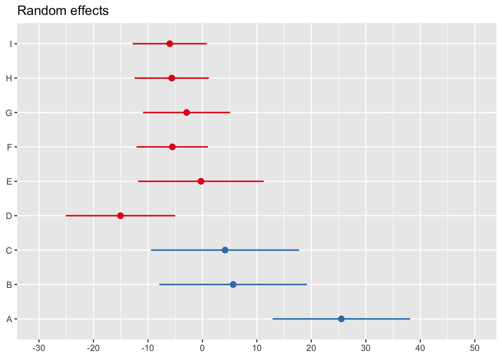

```r
# no differences in longevity in control vs. drought treatments
plot_model(mod_long_1, type = "re")
```